# Ontologies and Enrichment

Mark Dunning; mark ‘dot’ dunning ‘at’ cruk.cam.ac.uk, Oscar Rueda; oscar ‘dot’ rueda ‘at’ cruk.cam.ac.uk

Last modified: 14 Feb 2016

## Gene-Ontology Analysis

In this section we give an example of how to find a list of relevant pathways / GO terms from a list of differentially-expressed genes.

## Theory Part I: Over-representation analysis

- “Threshold-based”: require defintion of a statistical threshold to define list of genes to test (e.g. FDR < 0.01)
- Hypergeometric test, Fisher’s Exact test is used.

The question we are asking here is;

> *“Are the number of DE genes associated with Theme X significantly greater than what we might expect by chance alone?”*

Where Theme X could be genes belonging to a particular GO (Gene Onotology) term.

Let’s imagine that we have a bag full of balls. Each balls represents a gene in the *gene universe*. - Paint the balls representing our selected list grey, and paint the rest red.

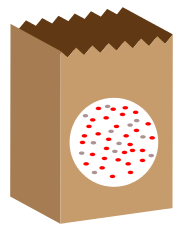

In this small example, we can define;

- Total number of balls: 40
- Total number of interesting (grey) balls: 10

Now, lets select a number (say, 12) of the balls at random without seeing into the bag and look at what we get

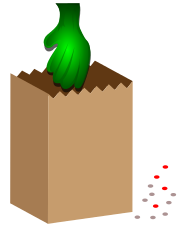

We have picked, at random, 8 grey balls. Using simulations, we can repeat the process and look at how many grey we get. We can (of course!) do this in R. In base R there is a family of functions that can generate random draws from various distributions; `rnorm`, `rbinom`, `rhyper` etc….

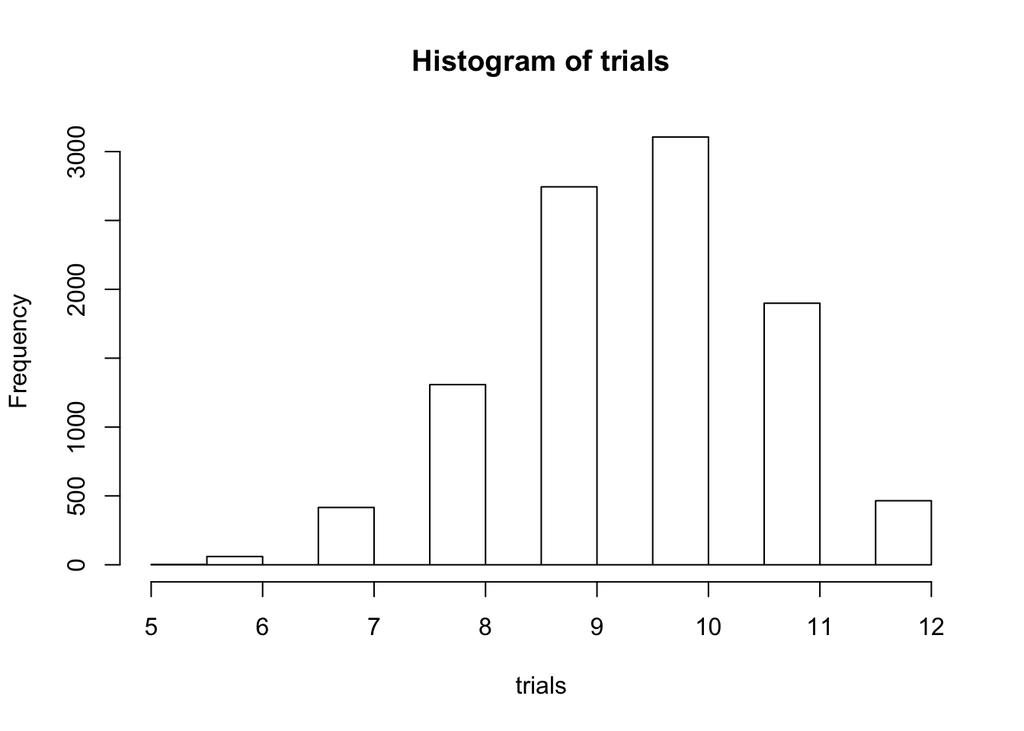

```r
#see ?rhyper for argument definition
trials <- rhyper(10000,40,10,12)
hist(trials)
```

```r
table(trials)
```

```
## trials
##    5    6    7    8    9   10   11   12
##    2   60  416 1308 2744 3106 1899  465
```

```r
table(trials)/10000
```

```
## trials
##      5      6      7      8      9     10     11     12
## 0.0002 0.0060 0.0416 0.1308 0.2744 0.3106 0.1899 0.0465
```

```r
cumsum(table(trials)/10000)
```

```
##      5      6      7      8      9     10     11     12
## 0.0002 0.0062 0.0478 0.1786 0.4530 0.7636 0.9535 1.0000
```

```r
1-cumsum(table(trials)/10000)
```

```
##      5      6      7      8      9     10     11     12
## 0.9998 0.9938 0.9522 0.8214 0.5470 0.2364 0.0465 0.0000
```

Back to our example, the distribution of balls can be expressed as a contingency table, on which we can use a Fisher’s exact test

Total grey balls: 10 Total in subset: 12

|  | Selection_in | Selection_out |
| --- | --- | --- |
| Grey_in | 8 | 2 |
| Grey_out | 4 | 26 |

|  | Selection_in | Selection_out | RowTotal |
| --- | --- | --- | --- |
| Grey_in | a | b | a +b |
| Grey_out | c | d | c+d |
| Column Total | a+c | b+d | a+b+c+d (=n) |

The formula for Fishers exact test is;

$p = \frac{\binom{a + b}{a}\binom{c +d}{c}}{\binom{n}{a +c}} = \frac{(a+b)!(c+d)!(a+c)!(b+d)!}{a!b!c!d!n!}$

or less formally;

*P = (ways of choosing grey balls) X (ways of non-grey balls amongst subset) / ways of choosing subset*

**Be careful of how you define the universe**

What genes were candidates for selection as universe?

- All possible genes
- All genes represented on the chip
- All genes that have a GO annotation
- All genes from the chip that pass a **non-specific** filter

Just changing the size of the universe alone can have a massive effect on the p-value

```r
## Code from Seth Falcon
P <- function(size){
  nFound <- 10
  nDrawn <- 400
  nAtCat <- 40
  nNotAtCat <- size - nAtCat
  phyper(nFound-1, nAtCat,nNotAtCat,nDrawn,lower.tail = FALSE)
}
P(1000)
```

```
## [1] 0.9860212
```

```r
P(5000)
```

```
## [1] 0.0009145082
```

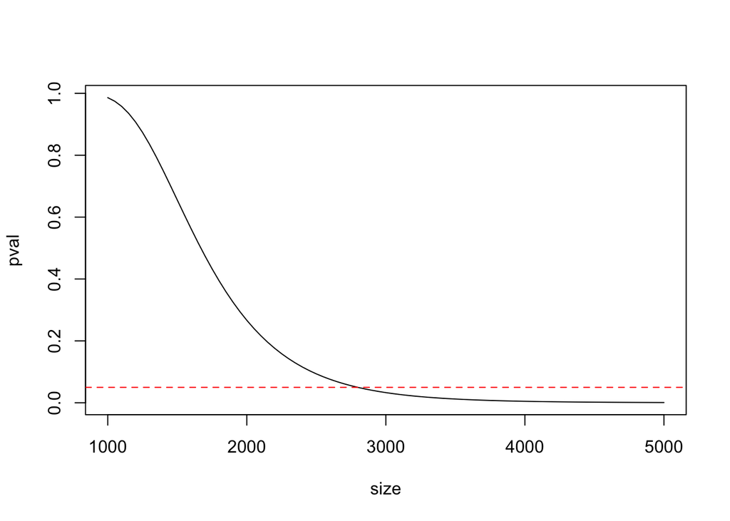

```r
ps <- sapply(seq(1000,5000,by=50),P)
plot(seq(1000,5000,by=50),ps,type="l",xlab="size",ylab="pval")
abline(h=0.05,lty=2,col="red")
```

## Preparing the data for an over-representation test

As before, we download the data from GEO.

```r
library(GEOquery)
library(genefilter)
url <- "ftp://ftp.ncbi.nih.gov/pub/geo/DATA/SeriesMatrix/GSE33126/GSE33126_series_matrix.txt.gz"
filenm <- "data/GSE33126_series_matrix.txt.gz"
if(!file.exists("data/GSE33126_series_matrix.txt.gz")) download.file(url, destfile=filenm)
colonData <- getGEO(filename=filenm)
```

```
## File stored at:
## /var/folders/b8/q7k4zz6d3x5bxrgwmst1vmmhdbgdr4/T//RtmpTcPKnR/GPL6947.soft
```

```r
colonData
```

```
## ExpressionSet (storageMode: lockedEnvironment)
## assayData: 48803 features, 18 samples
##   element names: exprs
## protocolData: none
## phenoData
##   sampleNames: GSM820516 GSM820517 ... GSM820533 (18 total)
##   varLabels: title geo_accession ... data_row_count (31 total)
##   varMetadata: labelDescription
## featureData
##   featureNames: ILMN_1343291 ILMN_1343295 ... ILMN_2416019 (48803
##     total)
##   fvarLabels: ID nuID ... GB_ACC (30 total)
##   fvarMetadata: Column Description labelDescription
## experimentData: use 'experimentData(object)'
## Annotation: GPL6947
```

Remember that we also need to do the log$_2$ transformation

```r
exprs(colonData) <- log2(exprs(colonData))
```

We will identify the probes that have an Entrez ID.

```r
anno <- fData(colonData)
anno <- anno[,c("Symbol","Entrez_Gene_ID","Chromosome","Cytoband")]
hasEntrez <- which(anno$Entrez_Gene_ID != "")
colonData.filt <- colonData[hasEntrez,]
```

In the following, we filter further by collapsing to unique Entrez IDs. The IQR is used as a criteria for selecting the *best* probe for each gene. To perform this selection we make use of the `apply` function in R. This is a convenient means of doing the same calculation for each row (or column) in a matrix. In our case, we want to calculate the IQR (using the `IQR` function) of each row in the matrix `exprs(colonData.filt)`.

```r
testStat <- apply(exprs(colonData.filt),1, IQR,na.rm=TRUE)
length(testStat)
```

```
## [1] 35280
```

Next we group together the iqrs for probes that represent the same Entrez ID. This we do using `split`. The result is a *list* with each item in the list containing the names of the probes for that Entrez ID and the IQRs.

```r
lls <- fData(colonData.filt)$Entrez_Gene_ID
tSsp = split.default(testStat, lls)
tSsp[[1]]
```

```
## ILMN_1736007 ILMN_2055271
##    0.1395741    0.2208207
```

```r
anno[names(tSsp[[1]]),]
```

```
##              Symbol Entrez_Gene_ID Chromosome  Cytoband
## ILMN_1736007   A1BG              1         19 19q13.43c
## ILMN_2055271   A1BG              1         19 19q13.43c
```

We can select the appropriate probe

```r
which.max(tSsp[[1]])
```

```
## ILMN_2055271
##            2
```

```r
names(which.max(tSsp[[1]]))
```

```
## [1] "ILMN_2055271"
```

```r
selectedID <- sapply(tSsp, function(x) names(which.max(x)))
selectedID[1]
```

```
##              1
## "ILMN_2055271"
```

We can then filter the `colonData.filt` object again.

```r
colonData.filt <- colonData.filt[unlist(selectedID),]
length(unique(fData(colonData.filt)$Entrez_Gene_ID))
```

```
## [1] 24384
```

```r
any(duplicated(fData(colonData.filt)$Entrez_Gene_ID))
```

```
## [1] FALSE
```

After this filtering, we are left with 24384 unique Entrez IDs. However, not all these genes will be expressed, or changing, in the conditions we are investigating.

It is also recommended to select probes with sufficient variability across samples to be interesting; as probes with little variability will no be interesting to the question we are trying to answer. The IQR of each probe across all arrays is commonly used for this. We will choose a cut-off of 0.25.

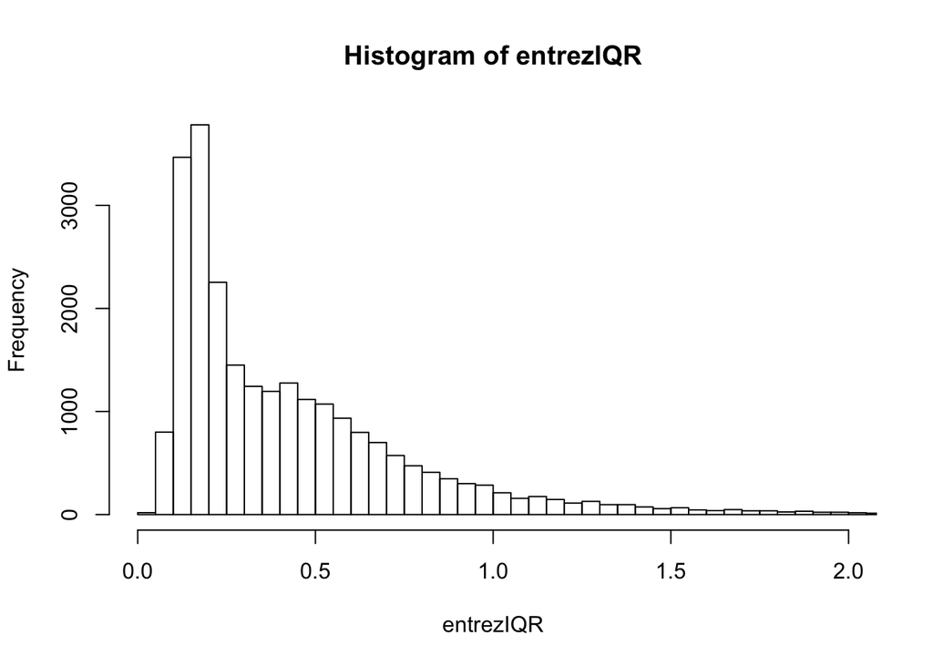

```r
entrezIQR = apply(exprs(colonData.filt), 1 , IQR)
hist(entrezIQR, xlim=c(0,2),breaks=100)
```

```r
colonData.filt <- colonData.filt[entrezIQR > 0.25,]
```

We’ll write-out the names of the Entrez genes that we have so we can use this as our *Gene Universe*.

```r
anno.final <- fData(colonData.filt)
universeIds <- anno.final$Entrez_Gene_ID
length(universeIds)
```

```
## [1] 14063
```

```r
write.table(universeIds, file="geneUniverse.txt",sep="\t",row.names = FALSE,quote=FALSE)
```

We’ve previously explained the following steps to produce a table of DE genes. However, for this analysis we are interested in a relatively long gene-list and do not need to be so stringent, so we can apply a standard t-test

```r
library(genefilter)
SampleGroup <- pData(colonData)$source_name_ch1
Patient <- pData(colonData)$characteristics_ch1.1

ttests <- rowttests(colonData.filt, fac=SampleGroup)
cutoff <- 0.01

selected <- ttests$p.value < cutoff
selectedEntrezIds <- fData(colonData.filt)$Entrez_Gene_ID[selected]
length(selectedEntrezIds)
```

```
## [1] 2622
```

## Using online tools

Even though this is a course advocating the use of R and Bioconductor, there are in fact many online tools that can assist with gene set analyses. [DAVID](https://david.ncifcrf.gov/) is a very popular tool and is able to accept gene lists in the form of Entrez IDs.

We write the selected Entrez IDs to a text file. So that the file is recognised by DAVID, we need to specify the argument `row.names=FALSE` to make sure that row numbers do not appear in the file.

```r
write.table(selectedEntrezIds, file="myEntrezGene.txt",sep="\t",quote=FALSE,row.names = FALSE)
```

You can upload this text file to the DAVID website, along with the gene universe we created previously, and follow the instructions.

## Over-representation analysis in Bioconductor: GOstats

The hyperGTest function is used to do the hypergeometric test for GO terms. Rather than passing a long list of parameters to the function. An object of type GOHyperGParams is created to hold all the parameters we need to run the hypergeometric test. This object can then be passed to hyperGTest multiple times without having to re-type the parameters each time. The meanings of these parameters are as follows:

- geneIds - The list of identifiers for the genes that we have selected as interesting
- universeGeneIds - The list of identifiers resulting from non-specific filtering
- annotation - The name of the annotation package that will be used
- ontology - The name of the GO ontology that will be tested; either BP, CC or MF
- pvaluecutoff - p-value that we will use to select significant GO terms
- testDirection - Either ”over” or ”under” for over or under represented terms respectively
- conditional - A more sophisticated form of hypergeometric test, which takes the relationships between terms in the GO graph can be used if this is set to TRUE. For this practical we will keep conditional = FALSE

```r
library(GOstats)
params = new ("GOHyperGParams" , geneIds = selectedEntrezIds ,
              universeGeneIds = universeIds , annotation = "illuminaHumanv3" ,
              ontology =  "BP" , pvalueCutoff = 0.05 , conditional = FALSE ,
              testDirection = "over")
hgOver = hyperGTest(params)
hgOver
```

```
## Gene to GO BP  test for over-representation
## 8800 GO BP ids tested (820 have p < 0.05)
## Selected gene set size: 2185
##     Gene universe size: 11205
##     Annotation package: illuminaHumanv3
```

The summary function can be used to view the results of the test in matrix form. The rows of the matrix are arranged in order of significance. The p-value is shown for each GO term along with with total number of genes for that GO term, number of genes we would be ex- pect to appear in the gene list by chance and that number that were observed. A descriptive name is also given for each term. The results can also be printed out to a HTML report us- ing htmlReport.

```r
summary (hgOver)[1:20 , ]
```

```
##        GOBPID       Pvalue OddsRatio  ExpCount Count Size
## 1  GO:0042254 1.884552e-08  2.604993  31.59036    62  162
## 2  GO:1903047 3.743433e-08  1.641586 134.94154   192  692
## 3  GO:0000278 2.436673e-07  1.548909 156.19679   213  801
## 4  GO:0022402 3.489211e-07  1.487120 190.90718   252  979
## 5  GO:0022613 6.128869e-07  1.978517  52.45560    86  269
## 6  GO:0000280 1.946894e-06  1.737423  76.24587   114  391
## 7  GO:0048285 2.797608e-06  1.694948  81.70593   120  419
## 8  GO:0007059 2.910751e-06  2.112924  37.24543    64  191
## 9  GO:0007067 3.403643e-06  1.809749  61.62071    95  316
## 10 GO:0000082 4.667849e-06  2.009964  41.53548    69  213
## 11 GO:0007049 6.111174e-06  1.366727 255.25792   316 1309
## 12 GO:0044772 6.867806e-06  1.707812  72.34583   107  371
## 13 GO:0006364 7.887102e-06  2.418545  23.40027    44  120
## 14 GO:0044770 8.161442e-06  1.685783  75.07586   110  385
```

[output cut: 27 more lines]

```r
keggParams = new ("KEGGHyperGParams" , geneIds = selectedEntrezIds ,
  universeGeneIds = universeIds , annotation = "illuminaHumanv3" ,
  pvalueCutoff = 0.05 , testDirection = "over" )

keggHgOver = hyperGTest (keggParams)

summary (keggHgOver)
```

[output not shown]

```
##    KEGGID       Pvalue OddsRatio  ExpCount Count Size
## 1   03008 4.048229e-08  4.170088 13.317569    33   64
## 2   00230 5.406881e-04  1.927853 27.675573    44  133
## 3   03030 1.232969e-03  3.209056  6.866872    15   33
## 4   03013 3.130507e-03  1.780737 25.802790    39  124
## 5   00140 4.333571e-03  2.938870  6.242611    13   30
## 6   04610 4.905378e-03  2.287420 10.612438    19   51
## 7   03050 6.468129e-03  2.507665  7.907307    15   38
## 8   00983 8.318179e-03  2.627937  6.658785    13   32
## 9   00982 9.152367e-03  2.164516 10.404351    18   50
## 10  04020 1.170094e-02  1.650238 24.346181    35  117
## 11  00830 1.473017e-02  2.376229  7.074959    13   34
## 12  00500 1.473017e-02  2.376229  7.074959    13   34
## 13  00980 1.655601e-02  2.041896 10.196264    17   49
## 14  04110 1.775003e-02  1.612691 23.305746    33  112
```

[output cut: 29 more lines]

```r
chrParams = new ("ChrMapHyperGParams" , geneIds = selectedEntrezIds ,
universeGeneIds = universeIds , annotation = "illuminaHumanv3" ,
pvalueCutoff = 0.05 , testDirection = "over" , conditional = TRUE )

chrHgOver = hyperGTest (chrParams)
summary (chrHgOver)
```

```
##    ChrMapID       Pvalue OddsRatio   ExpCount Count Size
## 1     16q13 6.109206e-06  7.387143  4.2303730    14   22
## 2    3p22.3 1.533445e-03  7.368946  2.1151865     7   11
## 3    Xq22.1 1.921719e-03  4.739206  3.2689246     9   17
## 4   Xp22.11 5.774303e-03 16.827642  0.9614484     4    5
## 5   6q22.32 7.102982e-03       Inf  0.5768690     3    3
## 6       16q 1.026710e-02  1.418544 51.3413454    67  267
## 7   12q14.2 1.468155e-02  8.413008  1.1537381     4    6
## 8   16q23.2 1.468155e-02  8.413008  1.1537381     4    6
## 9    8q21.2 1.468155e-02  8.413008  1.1537381     4    6
## 10        9 1.469173e-02  1.273464 99.9906352   120  520
## 11 15q22.31 1.563151e-02  2.915024  4.2303730     9   22
## 12      9p1 1.698008e-02  1.844914 13.2679881    21   69
## 13   9p13.3 2.040701e-02  2.297494  6.5378492    12   34
## 14    10p13 2.139158e-02  2.706546  4.4226627     9   23
```

[output cut: 24 more lines]

## Theory Part II: Threshold-free

For these tests, we don’t have to specify a statistical threshold and use the test statistics from *all* genes as the input to the test. The popular *Gene Set Enrichment Analysis (GSEA)* uses this approach. These tests can be used to detect differential expression for a group of genes, even when the effects are too small or there is too little data to detect the genes individually.

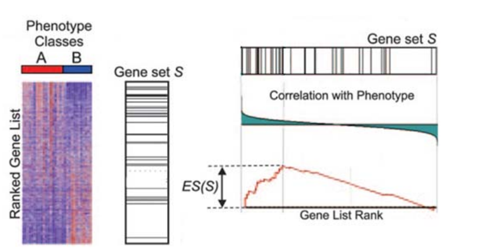

*Subramanian et al, PNAS 2005*

The Broad institute provides [a version of GSEA](http://software.broadinstitute.org/gsea/index.jsp) that can be run via a java application. However, it requires you to convert your data into a particular format. A more convenient option is [*GeneTrail*](http://genetrail.bioinf.uni-sb.de/enrichment_analysis.php?js=1&cc=1) which has the option to do a GSEA-style analysis.

The required input text contains a set of gene identifiers that are ordered according to some test statistic. To produce such a file, we first have to order the t-statistics from our test `ttests$statistic` with the `order` function.

```r
gseaList <- anno.final$Entrez_Gene_ID[order(ttests$statistic,decreasing = TRUE)]
write.table(gseaList, file="genetrail-gsea.txt",sep="\t",row.names = FALSE,quote=FALSE)
```

Note that Genetrail can also be used for the Over-Representation analysis that we saw in the previous section.

## A Threshold-free test in Bioconductor

A simple version of this test is implemented in the `geneSetTest` function in `limma`, which computes a p-value to test the hypothesis that the selected genes have more extreme test-statistics than one might expect by chance. Moreover, separate tests can be performed to see if the selected genes are up-regulated (`alternative=up`) or down-regulated (`alternative=down`). The default is to test for extreme statistics regardless of sign.

To demonstrate, we will pick 50 genes at random. We have to supply the entire set of test statistics along indices of interest. The result of the `barcode` plot below shows there is no particular trend for genes we have picked be up- or down-regulated.

```r
library (limma)

randGenes <- sample(1:nrow(ttests),50)

geneSetTest (index = randGenes , statistics = ttests$statistic)
```

```
## [1] 0.4841681
```

```r
geneSetTest (index = randGenes , statistics = ttests$statistic ,
  alternative = "down" )
```

```
## [1] 0.8885377
```

```r
geneSetTest (index = randGenes , statistics = ttests$statistic ,
  alternative = "up" )
```

```
## [1] 0.1114689
```

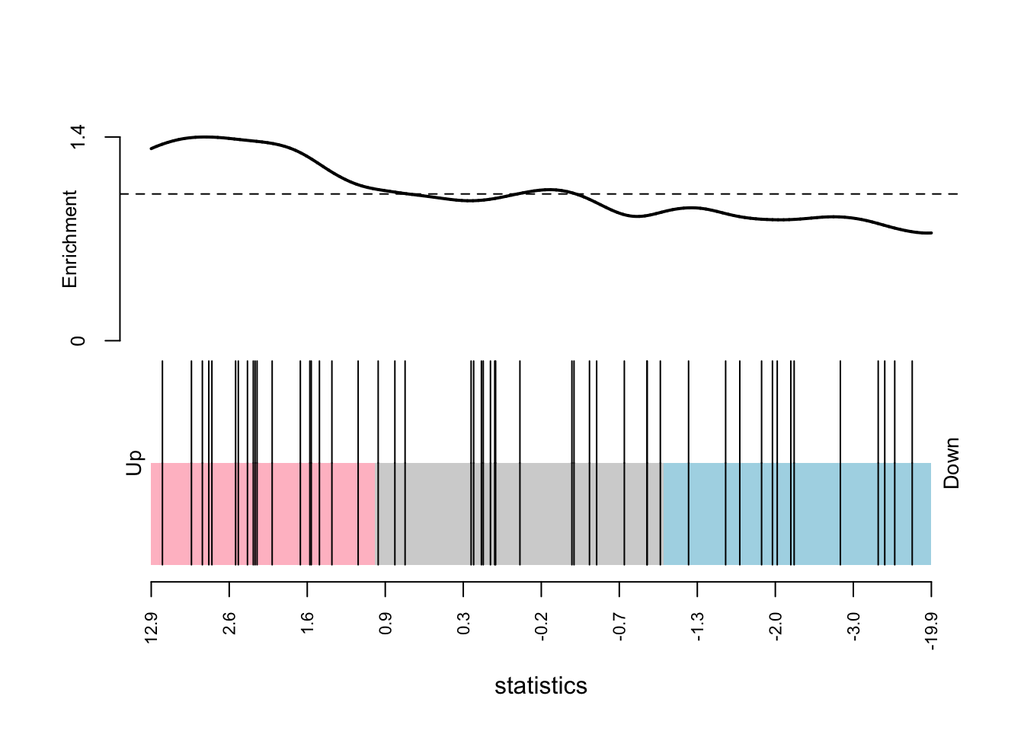

```r
barcodeplot (statistics = as.numeric(ttests$statistic) , index = randGenes )
```

On the other hand, we could deliberately pick genes with a significant p-value and notice how the results are altered.

```r
myGenes <- which(ttests$p.value < 0.01)[1:50]

geneSetTest (index = myGenes , statistics = ttests$statistic)
```

```
## [1] 1.880315e-24
```

```r
geneSetTest (index = myGenes , statistics = ttests$statistic ,
  alternative = "down" )
```

```
## [1] 0.08940683
```

```r
geneSetTest (index = myGenes , statistics = ttests$statistic ,
  alternative = "up" )
```

```
## [1] 0.9105988
```

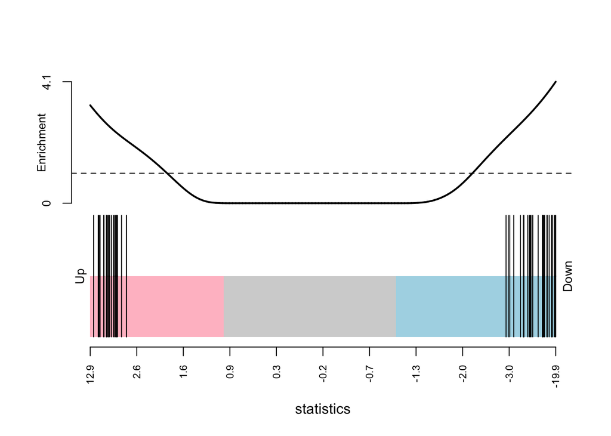

```r
barcodeplot (statistics = as.numeric(ttests$statistic) , index = myGenes )
```

We have already seen of example of searching for particular gene symbols in our output tables.

```r
mylist <- c("LOC441066","ARF3","FMNL3","CSF1R","XLKD1","TTRAP","DMWD","SYNPO2L","PILRB","LAMP3")
myGenes <- which(anno.final$Symbol %in% mylist)
geneSetTest (index = myGenes , statistics = ttests$statistic)
```

```
## [1] 0.9966446
```

```r
geneSetTest (index = myGenes , statistics = ttests$statistic ,
  alternative = "down" )
```

```
## [1] 0.8526797
```

```r
geneSetTest (index = myGenes , statistics = ttests$statistic ,
  alternative = "up" )
```

```
## [1] 0.1473404
```

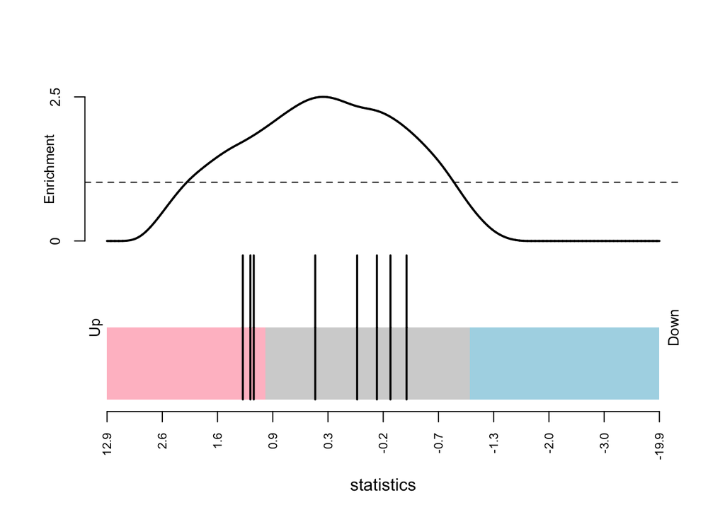

```r
barcodeplot (statistics = as.numeric(ttests$statistic) , index = myGenes )
```

## Converting between different identifiers

There are facilities in Bioconductor for converting between different identifier (e.g. Entrez, Ensembl, Unigene) schemes. For each organism, there is a pre-built *database* package that allows various queries to be made. In this example, we will use the `org.Hs.eg.db` package for humans. Other organisms can be found on the list of [Bioconductor annotation packages](http://bioconductor.org/packages/release/BiocViews.html#___AnnotationData); just look for packages that start *org.*.

An advantage of using these packages, rather than web services such as biomart, is that offline queries are possible.

Each organism has a series of *columns* and *keys* defined. The *keys* are the identifers that you want to query, and the *columns* define the information that you want to retrieve.

```r
library(org.Hs.eg.db)
columns(org.Hs.eg.db)
```

```
##  [1] "ENTREZID"     "PFAM"         "IPI"          "PROSITE"
##  [5] "ACCNUM"       "ALIAS"        "CHR"          "CHRLOC"
##  [9] "CHRLOCEND"    "ENZYME"       "MAP"          "PATH"
## [13] "PMID"         "REFSEQ"       "SYMBOL"       "UNIGENE"
## [17] "ENSEMBL"      "ENSEMBLPROT"  "ENSEMBLTRANS" "GENENAME"
## [21] "UNIPROT"      "GO"           "EVIDENCE"     "ONTOLOGY"
## [25] "GOALL"        "EVIDENCEALL"  "ONTOLOGYALL"  "OMIM"
## [29] "UCSCKG"
```

```r
keytypes(org.Hs.eg.db)
```

```
##  [1] "ENTREZID"     "PFAM"         "IPI"          "PROSITE"
##  [5] "ACCNUM"       "ALIAS"        "ENZYME"       "MAP"
##  [9] "PATH"         "PMID"         "REFSEQ"       "SYMBOL"
## [13] "UNIGENE"      "ENSEMBL"      "ENSEMBLPROT"  "ENSEMBLTRANS"
## [17] "GENENAME"     "UNIPROT"      "GO"           "EVIDENCE"
## [21] "ONTOLOGY"     "GOALL"        "EVIDENCEALL"  "ONTOLOGYALL"
## [25] "OMIM"         "UCSCKG"
```

Lets’ find out what the Entrez ID’s are for the genes *TP53*, *BRCA1* and *PTEN*. We specify our `keys` as the vector of these names, our `keytype` is `SYMBOL` (which must be in the result we get back from doing `keytypes`) and the `columns` is `ENTREZID`.

```r
select(org.Hs.eg.db, keys=c("TP53","BRCA1","PTEN"), keytype = "SYMBOL",columns = "ENTREZID")
```

```
##   SYMBOL ENTREZID
## 1   TP53     7157
## 2  BRCA1      672
## 3   PTEN     5728
```

We can choose to return multiple bits of information by changing the `columns` argument. In some cases though, you could get many results returned for the same key.

```r
select(org.Hs.eg.db, keys=c("TP53","BRCA1","PTEN"), keytype = "SYMBOL",columns = c("ENTREZID","ENSEMBL","UNIPROT"))
```

```
##    SYMBOL ENTREZID         ENSEMBL    UNIPROT
## 1    TP53     7157 ENSG00000141510     K7PPA8
## 2    TP53     7157 ENSG00000141510     P04637
## 3    TP53     7157 ENSG00000141510     Q53GA5
## 4    TP53     7157 ENSG00000141510     H2EHT1
## 5    TP53     7157 ENSG00000141510 A0A087X1Q1
## 6    TP53     7157 ENSG00000141510 A0A087WXZ1
## 7    TP53     7157 ENSG00000141510 A0A087WT22
## 8   BRCA1      672 ENSG00000012048     P38398
## 9   BRCA1      672 ENSG00000012048     E9PFZ0
## 10  BRCA1      672 ENSG00000012048 A0A024R1V0
## 11   PTEN     5728 ENSG00000171862     F6KD01
## 12   PTEN     5728 ENSG00000171862     P60484
```

We can find out which genes belong to a particular path. e.g. the *Cell Cycle* pathway is KEGG: 04110 and the `keytype` is `PATH`.

```r
select(org.Hs.eg.db, keys="04110", keytype = "PATH",columns=c("SYMBOL","ENTREZID"))
```

```
##      PATH  SYMBOL ENTREZID
## 1   04110    ABL1       25
## 2   04110     ATM      472
## 3   04110     ATR      545
## 4   04110   CCND1      595
## 5   04110    BUB1      699
## 6   04110   BUB1B      701
## 7   04110   CCNA2      890
## 8   04110   CCNB1      891
## 9   04110   CCND2      894
## 10  04110   CCND3      896
## 11  04110   CCNE1      898
## 12  04110    CCNH      902
## 13  04110    CDK1      983
## 14  04110    CDC6      990
```

[output cut: 110 more lines]

Gene-Ontology terms can be queried using the `GOALL` keytype. Also returned in the result are the GO *evidence codes* and ontology type (BP = Biological Process, MF = Molecular Function).

For example, we might be interested in the GO term *GO:0016072* and be interested in whether these genes are up- or down-regulated in our study. The first step would be to retrieve the Entrez IDs that correspond to this term.

```r
goQuery <- select(org.Hs.eg.db, keys="GO:0016072", keytype = "GOALL",columns=c("SYMBOL","ENTREZID"))
head(goQuery)
```

```
##        GOALL EVIDENCEALL ONTOLOGYALL SYMBOL ENTREZID
## 1 GO:0016072         IEA          BP   BYSL      705
## 2 GO:0016072         IEA          BP CDKN2A     1029
## 3 GO:0016072         IBA          BP   DKC1     1736
## 4 GO:0016072         TAS          BP   DKC1     1736
## 5 GO:0016072         IBA          BP    FBL     2091
## 6 GO:0016072         TAS          BP    FBL     2091
```

We can match these Entrez IDs to our annotation object and proceed as before.

```r
myGenes <- which(anno.final$Entrez %in% goQuery$ENTREZ)
geneSetTest (index = myGenes , statistics = ttests$statistic)
```

```
## [1] 2.279536e-10
```